# Data on Cars used for Testing Fuel Economy

# Introduction

### The test data used to determine fuel economy is derived from vehicle testing done at EPA's National Vehicle and Fuel Emissions Laboratory in Ann Arbor, Michigan, and by vehicle manufacturers who submit their own test data to EPA.

## Preliminary Wrangling

```python
import warnings
warnings.filterwarnings('ignore')
import numpy as np
import pandas as pd
import matplotlib.pyplot as plt, seaborn as sb

%matplotlib inline
```

```python
df=pd.read_csv('clean_18.csv')
```

### What is the structure of your dataset?

this dataset contains 832 rows with 13 features that shows properties about varieties of cars in 2018 sume of these features about model cars are: kind of fuel of car, number of engine cylinders, number of wheel Drive, vehicle classes and ...

### What is/are the main feature(s) of interest in your dataset?

the most important factors in this dataset are air pollution score and grean house score and fuel that can have effect making decision to produce cars using other features.

### What features in the dataset do you think will help support your investigation into your feature(s) of interest?

some of my expectations about these dataset variables would be that, kind of fuel, engine displacement in liters(displ) or veh_class of cars can effect on air pollution acore. beside it other numeric values are in this dataset that we want to know about theit relations with others like city fuel economy in miles per gallon (city_mpg) , ...

### cleaning if it is requared

```python
df.shape
```

```
(832, 13)
```

this dataset has been already cleaned. but if we want to make sure, check some of important element for this

```python
df.head()
```

|  | model | displ | cyl | trans | drive | fuel | veh_class | air_pollution_score | city_mpg | hwy_mpg | cmb_mpg | greenhouse_gas_score | smartway |
| --- | --- | --- | --- | --- | --- | --- | --- | --- | --- | --- | --- | --- | --- |
| 0 | ACURA RDX | 3.5 | 6 | SemiAuto-6 | 2WD | Gasoline | small SUV | 3.0 | 20.0 | 28.0 | 23.0 | 5 | No |
| 1 | ACURA RDX | 3.5 | 6 | SemiAuto-6 | 4WD | Gasoline | small SUV | 3.0 | 19.0 | 27.0 | 22.0 | 4 | No |
| 2 | ACURA TLX | 2.4 | 4 | AMS-8 | 2WD | Gasoline | small car | 3.0 | 23.0 | 33.0 | 27.0 | 6 | No |
| 3 | ACURA TLX | 3.5 | 6 | SemiAuto-9 | 2WD | Gasoline | small car | 3.0 | 20.0 | 32.0 | 24.0 | 5 | No |
| 4 | ACURA TLX | 3.5 | 6 | SemiAuto-9 | 4WD | Gasoline | small car | 3.0 | 21.0 | 30.0 | 24.0 | 5 | No |

first of all we need to check type of variables and check them out whether we have missing data or not

```python
df.info()
```

```
<class 'pandas.core.frame.DataFrame'>
RangeIndex: 832 entries, 0 to 831
Data columns (total 13 columns):
 #   Column                Non-Null Count  Dtype
---  ------                --------------  -----
 0   model                 832 non-null    object
 1   displ                 832 non-null    float64
 2   cyl                   832 non-null    int64
 3   trans                 832 non-null    object
 4   drive                 832 non-null    object
 5   fuel                  832 non-null    object
 6   veh_class             832 non-null    object
 7   air_pollution_score   832 non-null    float64
 8   city_mpg              832 non-null    float64
 9   hwy_mpg               832 non-null    float64
 10  cmb_mpg               832 non-null    float64
 11  greenhouse_gas_score  832 non-null    int64
 12  smartway              832 non-null    object
dtypes: float64(5), int64(2), object(6)
memory usage: 84.6+ KB
```

some fields in this dataset are really important for us to get relations. quantitative fields are: 'displ','air_pollution_score','city_mpg','hwy_mpg','greenhouse_gas_score' qualitative fielas are: 'cyl','drive','fuel','veh_class'

```python
var_numeric=['displ','air_pollution_score','city_mpg','hwy_mpg','greenhouse_gas_score']
var_ordinal=['cyl','drive','fuel','veh_class']
```

using boxplot we can undesrtand we have outlier data in our numeric fields or not

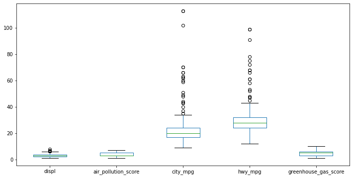

```python
df[var_numeric].plot.box(figsize=[12,6]);
```

by analysis of boxplots, we figured out that 3 fields we need to remove outliers

```python
def quan_func(x):
    q_25,q_50,q_75 = x.quantile([0.25,0.50,0.75])
    iqr=q_75-q_25
    return q_25-1.5*iqr,q_75+1.5*iqr
```

remove all of outlier data from 3 columns (city_mpg , hwy_mpg , displ)

```python
df0=df[df[df.city_mpg>=quan_func(df.city_mpg)[0]].city_mpg<=quan_func(df.city_mpg)[1]]
df1=df0[df0[df0.hwy_mpg>=quan_func(df0.hwy_mpg)[0]].hwy_mpg<=quan_func(df0.hwy_mpg)[1]]
df2=df1[df1[df1.displ>=quan_func(df1.displ)[0]].displ<=quan_func(df1.displ)[1]]
```

```python
# we understand we removed 67 outlier data
df2.shape
```

```
(765, 13)
```

final check for outlier data:

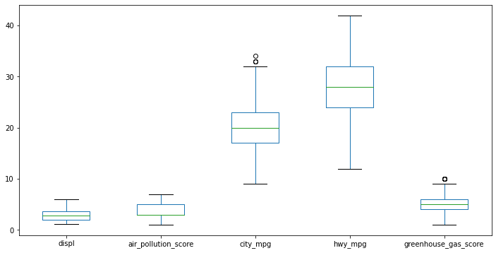

```python
df2[var_numeric].plot.box(figsize=[12,6]);
# all of the big outliers were removed
```

```python
data_ordinal={}
for i in range(len(var_ordinal)):
    data_ordinal[var_ordinal[i]]=df2[var_ordinal[i]].unique()
```

```python
for var in data_ordinal:
    pd_ver=pd.__version__.split(".")
    if (int(pd_ver[0])>0) or (int(pd_ver[1])>21):
        order_var=pd.api.types.CategoricalDtype(ordered=True,categories=data_ordinal[var])
        df2[var]=df2[var].astype(order_var)
    else:
        df2[var]=df[var].astype('category',ordered=True,categories=data_ordinal[var])
```

```python
df2.info()
```

```
<class 'pandas.core.frame.DataFrame'>
Int64Index: 765 entries, 0 to 828
Data columns (total 13 columns):
 #   Column                Non-Null Count  Dtype
---  ------                --------------  -----
 0   model                 765 non-null    object
 1   displ                 765 non-null    float64
 2   cyl                   765 non-null    category
 3   trans                 765 non-null    object
 4   drive                 765 non-null    category
 5   fuel                  765 non-null    category
 6   veh_class             765 non-null    category
 7   air_pollution_score   765 non-null    float64
 8   city_mpg              765 non-null    float64
 9   hwy_mpg               765 non-null    float64
 10  cmb_mpg               765 non-null    float64
 11  greenhouse_gas_score  765 non-null    int64
 12  smartway              765 non-null    object
dtypes: category(4), float64(5), int64(1), object(3)
memory usage: 63.6+ KB
```

## Univariate Exploration

first of all we should explore univariate as we got, we have 4 categorical fields and 5 numeric fields

```python
color_base=sb.color_palette()[0]
```

## how many ordinal varables we have from their categories?

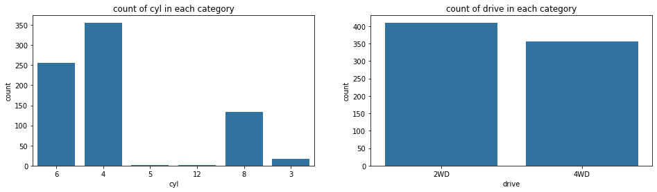

```python
fig , ax = plt.subplots(ncols=2 , figsize=[16,4])
for i in range(0,2):
    sb.countplot(data=df2 , x=var_ordinal[i] , color=color_base , ax=ax[i])
    ax[i].set_title("count of "+var_ordinal[i]+" in each category")
    if var_ordinal[i]=='veh_class':
        plt.xticks(rotation=90)
plt.show()
```

### for number of engine cylinders (cly) cylinder with number 4 is the most and 5 and 12 are minimum count of cars in our dataset. about the number of wheel drive, number of car in 2WD is more than 4WD

## how many ordinal varables we have from their categories?

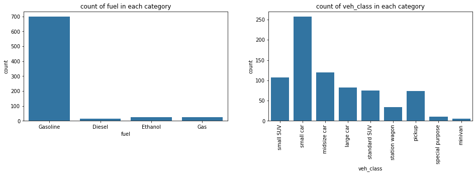

```python
fig , ax = plt.subplots(ncols=2 , figsize=[16,4])
for i in range(2,len(var_ordinal)):
    sb.countplot(data=df2 , x=var_ordinal[i] , color=color_base , ax=ax[i-2])
    ax[i-2].set_title("count of "+var_ordinal[i]+" in each category")
    if var_ordinal[i]=='veh_class':
        plt.xticks(rotation=90)
plt.show()
```

### Gasoline has the maximum grade for kind of fuel. this has biggest different in compare to other maximum. in the final chart about class of wehicles, small car has the maximum rating. if we ignore small car, we can understand that with increasing size of car, number of them is decreasing approximately

we need to make a dictionary to match any unit of numeric variable

```python
unit_var={'displ':'(liters)','air_pollution_score':'(MY)','city_mpg':'(miles per gallon)','hwy_mpg':'(miles per gallon)','greenhouse_gas_score':'(MY)'}
```

## what is the distribution of each numeric variable? (behaviour of variable)

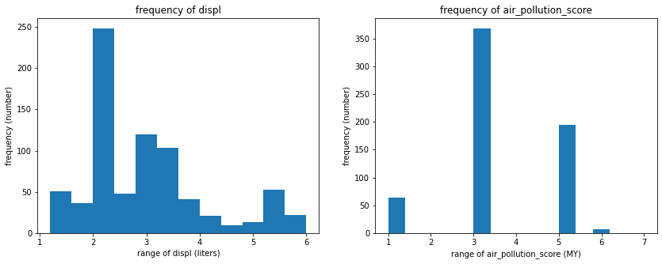

```python
fig , ax = plt.subplots(ncols=2 , figsize=[14,5])
for i in range(2):
    my_bin=np.arange(min(df2[var_numeric[i]]),max(df2[var_numeric[i]])+0.4,0.4)
    ax[i].hist(data=df2, x=var_numeric[i],bins=my_bin)
    ax[i].set_ylabel("frequency (number)")
    ax[i].set_xlabel("range of "+var_numeric[i]+' '+unit_var[var_numeric[i]])
    ax[i].set_title("frequency of "+var_numeric[i])
plt.show()
```

### for analysis of numeric variables, we should use histogram. because of all of the histograms are not long-tailed distribution, we do not use log scale for them. that is why we use top charts for our analysis. about displ we see majority of cars have approximately engine displacement in liters between 2 and 2.5 and the second maximum was happened between 3 and 4. for score of air pollution we got it that number 3 and alittle bit more than 3 are the highest score.

## what is the distribution of each numeric variable? (behaviour of variable)

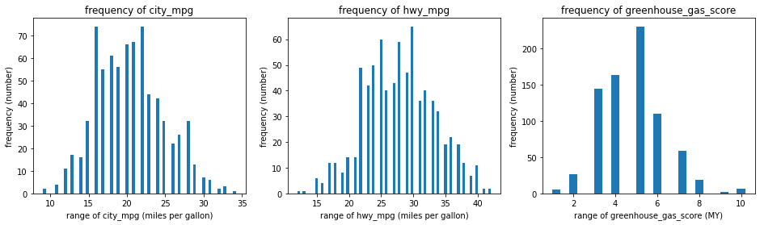

```python
fig , ax = plt.subplots(ncols=3 , figsize=[16,4])
for i in range(2,len(var_numeric)):
    my_bin=np.arange(min(df2[var_numeric[i]]),max(df2[var_numeric[i]])+0.4,0.4)
    ax[i-2].hist(data=df2, x=var_numeric[i],bins=my_bin)
    ax[i-2].set_ylabel("frequency (number)")
    ax[i-2].set_xlabel("range of "+var_numeric[i]+' '+unit_var[var_numeric[i]])
    ax[i-2].set_title("frequency of "+var_numeric[i])
plt.show()
```

### distribution of city_mpg is look alike normal distribution.maximum city_mpg is happened in mean of data that is close to median of data (between 15 to 22). minimum of number of cars are close to 10 and 33. like city_mpg, we have similar analysis for hwy_mpg. maximum range of it occured between 25 to 30. for greenhouse gas score we have distribution like normal as well. maximum number score is about 5 and minimum score is about 9 and 1

### Discuss the distribution(s) of your variable(s) of interest. Were there any unusual points? Did you need to perform any transformations?

as we drawed of all distributions, 3 of them made histogram like normal. and others chart are readable and we got maximum and minimum point of them

## Bivariate Exploration

To start off with, I want to look at the pairwise correlations present between features in the data

## overview correlations present between features in the data

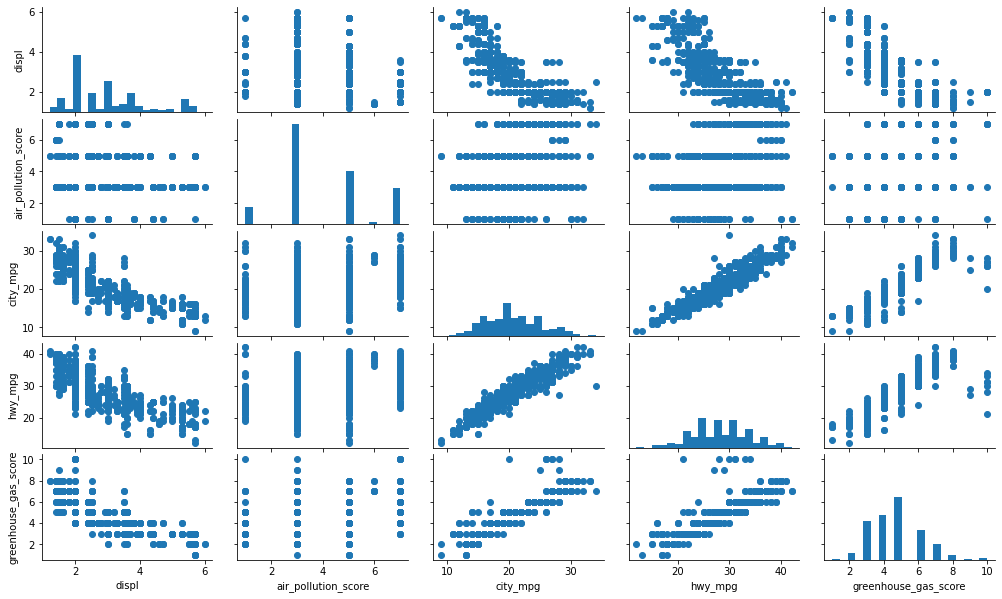

```python
g=sb.PairGrid(data=df2,vars=var_numeric)
g.map_diag(plt.hist,bins=20)
g.map_offdiag(plt.scatter)
# Set Plot Dimensions - FIGURE LEVEL
g.fig.set_size_inches(14, 8);
plt.show()
```

### city_mpg and hwy_mpg are highly correlated. both of these variable are about fuel economy in miles per gallon and it is not surprising to see this high correlation. the correlation between displ and city_mpg and hwy_mpg are negative

## HeatMap correlations present between features in the data

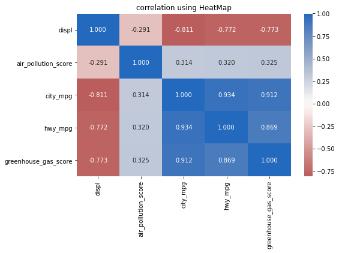

```python
plt.figure(figsize = [8, 5])
sb.heatmap(df2[var_numeric].corr(), annot = True, fmt = '.3f',
           cmap = 'vlag_r', center = 0)
plt.title("correlation using HeatMap")
plt.show()
```

### it shows relationship between numeric variables that we have already mentioned

as we saw in exploration relation between variables by PairGrid, we want to focous these numeric variables buy another view of their relation. now we visual them by scatter plot to got more details about them

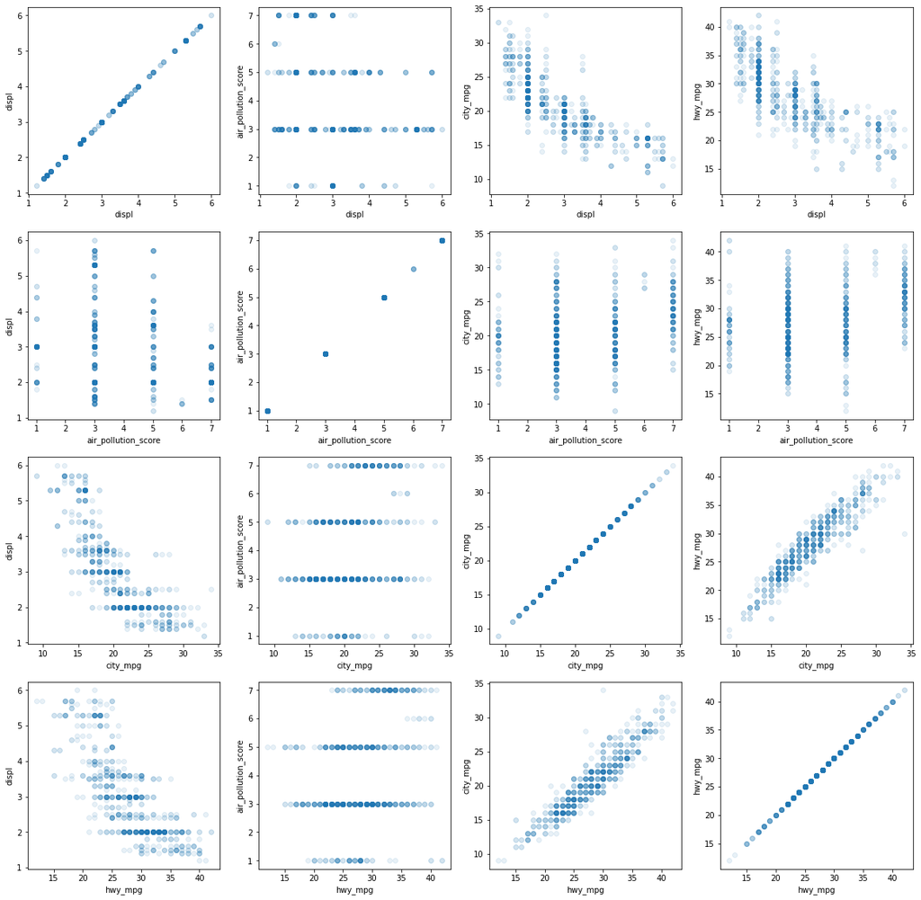

```python
fig,ax = plt.subplots(nrows=4 , ncols=4 , figsize=[20,20])
for i in range (4):
    for j in range (4):
        ax[i,j].scatter(data=df2, x= var_numeric[i],y=var_numeric[j],alpha=1/10)
        ax[i,j].set_xlabel(var_numeric[i])
        ax[i,j].set_ylabel(var_numeric[j])

plt.show()
```

in these chart we can see some of the details about the relations. the negative trend between displ and hwy_mpg happened in second second half of hwy_mpg. majority of cars that contain negative coefficient between displ and city_mpg, are occured in first half of city_mpg

## comparing number of engine and all numeric variables

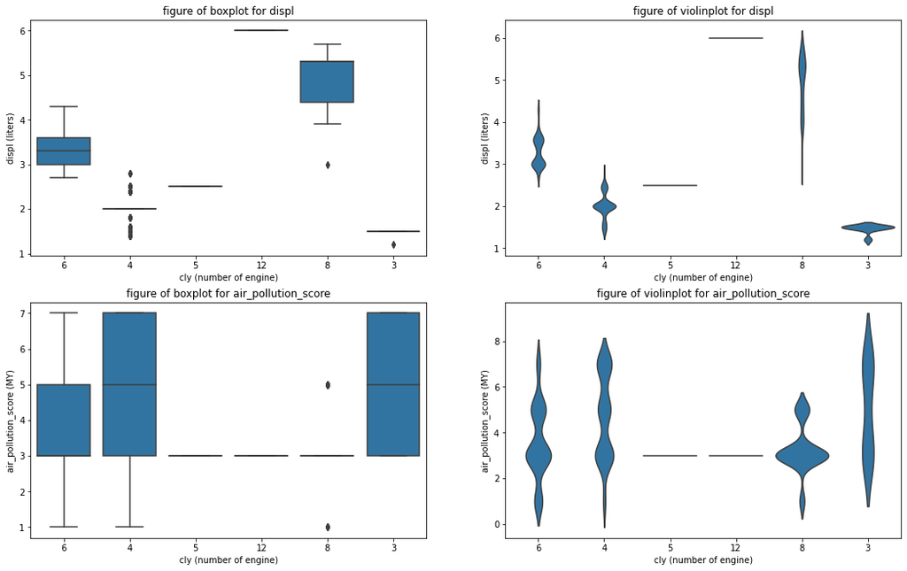

```python
fig,ax = plt.subplots(nrows=2, ncols=2 , figsize=[18,11])
for j in range(2):
    for i in range(2):
        if j==0:
            sb.boxplot(data=df2,x='cyl',y=var_numeric[i],color=color_base, ax=ax[i,j])
            ax[i,j].set_title('figure of boxplot for '+var_numeric[i])
        else:
            sb.violinplot(data=df2,x='cyl',y=var_numeric[i],color=color_base, inner=None, ax=ax[i,j])
            ax[i,j].set_title('figure of violinplot for '+var_numeric[i])
        ax[i,j].set_xlabel('cly (number of engine)')
        ax[i,j].set_ylabel(var_numeric[i]+' '+unit_var[var_numeric[i]])
plt.show()
```

### given these chart, we found first negative and after that positive relation between this variable

## comparing number of engine and all numeric variables

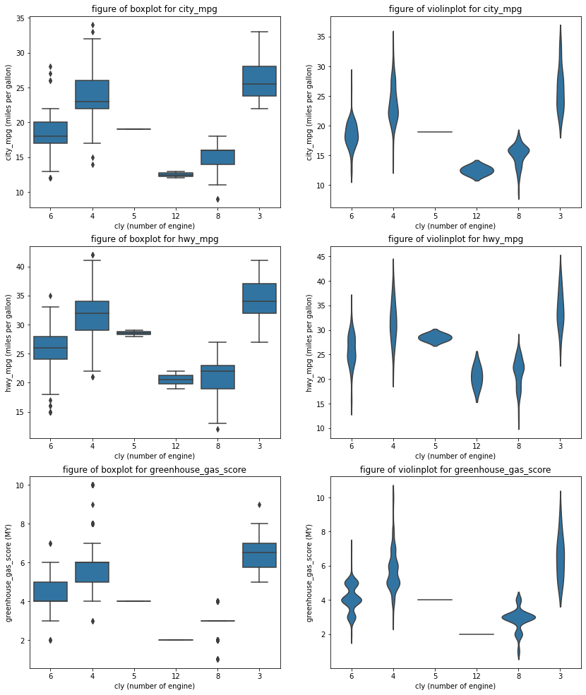

```python
fig,ax = plt.subplots(nrows=3, ncols=2 , figsize=[14,17])
for j in range(2):
    for i in range(2,5):
        if j==0:
            sb.boxplot(data=df2,x='cyl',y=var_numeric[i],color=color_base, ax=ax[i-2,j])
            ax[i-2,j].set_title('figure of boxplot for '+var_numeric[i])
        else:
            sb.violinplot(data=df2,x='cyl',y=var_numeric[i],color=color_base, inner=None, ax=ax[i-2,j])
            ax[i-2,j].set_title('figure of violinplot for '+var_numeric[i])
        ax[i-2,j].set_xlabel('cly (number of engine)')
        ax[i-2,j].set_ylabel(var_numeric[i]+' '+unit_var[var_numeric[i]])
plt.show()
```

we compare all of numeric variables with number of engine cylinders that it is categirical variable. given these chart, we found negative relation between this variable and city_mpg, hwy_mpg and approximately greenhouse gas score.

## comparing number of wheel drive and all numeric variables

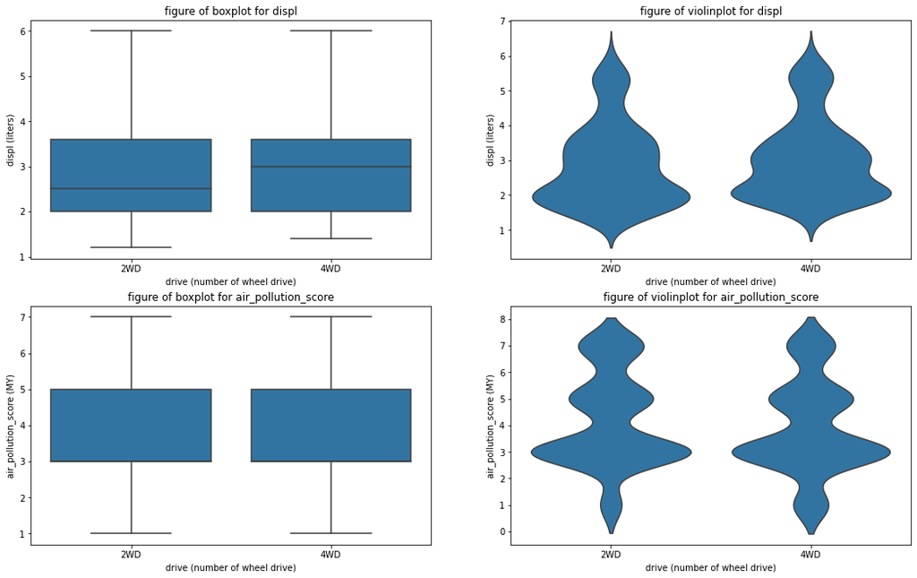

```python
fig,ax = plt.subplots(nrows=2, ncols=2 , figsize=[18,11])
for j in range(2):
    for i in range(2):
        if j==0:
            sb.boxplot(data=df2,x='drive',y=var_numeric[i],color=color_base, ax=ax[i,j])
            ax[i,j].set_title('figure of boxplot for '+var_numeric[i])
        else:
            sb.violinplot(data=df2,x='drive',y=var_numeric[i],color=color_base, inner=None, ax=ax[i,j])
            ax[i,j].set_title('figure of violinplot for '+var_numeric[i])
        ax[i,j].set_xlabel('drive (number of wheel drive)')
        ax[i,j].set_ylabel(var_numeric[i]+' '+unit_var[var_numeric[i]])
plt.show()
```

## comparing number of wheel drive and all numeric variables

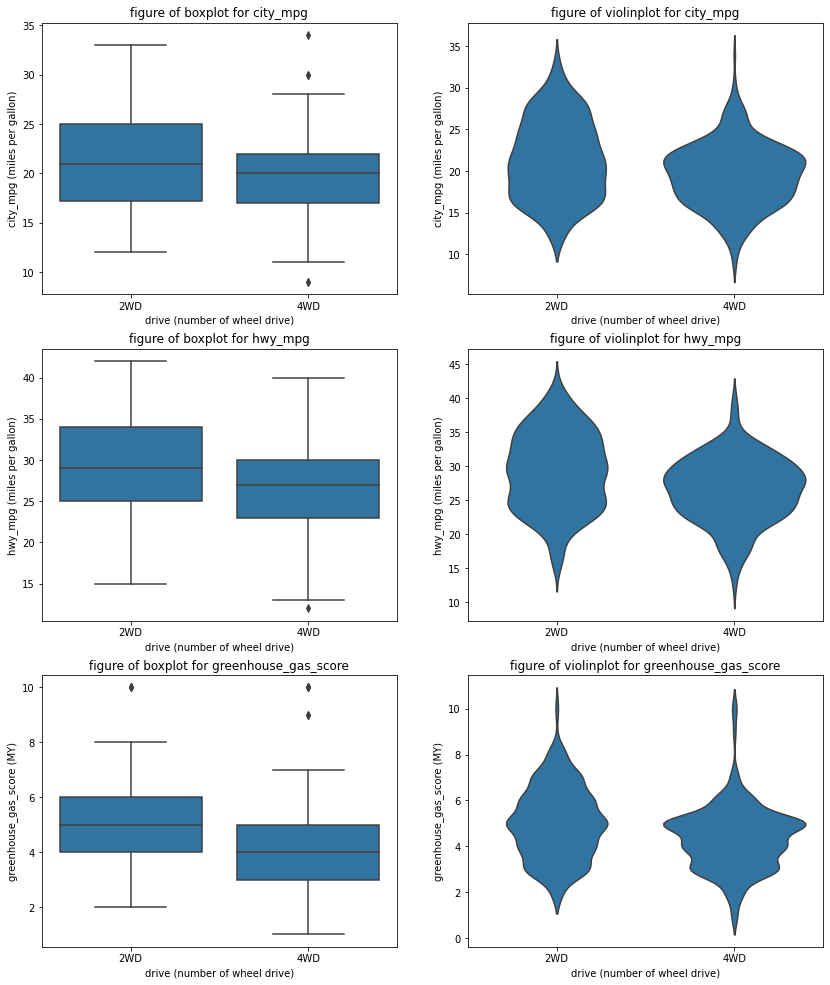

```python
fig,ax = plt.subplots(nrows=3, ncols=2 , figsize=[14,17])
for j in range(2):
    for i in range(2,5):
        if j==0:
            sb.boxplot(data=df2,x='drive',y=var_numeric[i],color=color_base, ax=ax[i-2,j])
            ax[i-2,j].set_title('figure of boxplot for '+var_numeric[i])
        else:
            sb.violinplot(data=df2,x='drive',y=var_numeric[i],color=color_base, inner=None, ax=ax[i-2,j])
            ax[i-2,j].set_title('figure of violinplot for '+var_numeric[i])
        ax[i-2,j].set_xlabel('drive (number of wheel drive)')
        ax[i-2,j].set_ylabel(var_numeric[i]+' '+unit_var[var_numeric[i]])
plt.show()
```

in this part we compare all of numeric variables with number of wheel drive that it is another categirical variable. given these chart, we can find any special relation between them. both of 2WD and 4WD have the same air pollution score. but for greenhouse gas score, we have this score for 4WD less than 2WD

## comparing number of fuel and all numeric variables

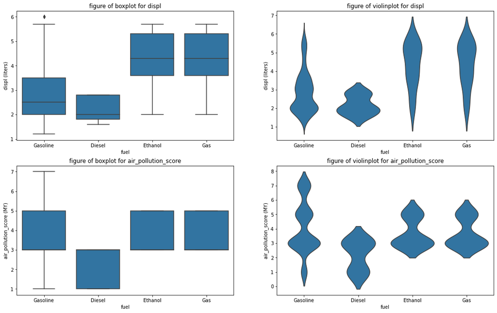

```python
fig,ax = plt.subplots(nrows=2, ncols=2 , figsize=[18,11])
for j in range(2):
    for i in range(2):
        if j==0:
            sb.boxplot(data=df2,x='fuel',y=var_numeric[i],color=color_base, ax=ax[i,j])
            ax[i,j].set_title('figure of boxplot for '+var_numeric[i])
        else:
            sb.violinplot(data=df2,x='fuel',y=var_numeric[i],color=color_base, inner=None, ax=ax[i,j])
            ax[i,j].set_title('figure of violinplot for '+var_numeric[i])
        ax[i,j].set_xlabel('fuel')
        ax[i,j].set_ylabel(var_numeric[i]+' '+unit_var[var_numeric[i]])
plt.show()
```

## comparing number of fuel and all numeric variables

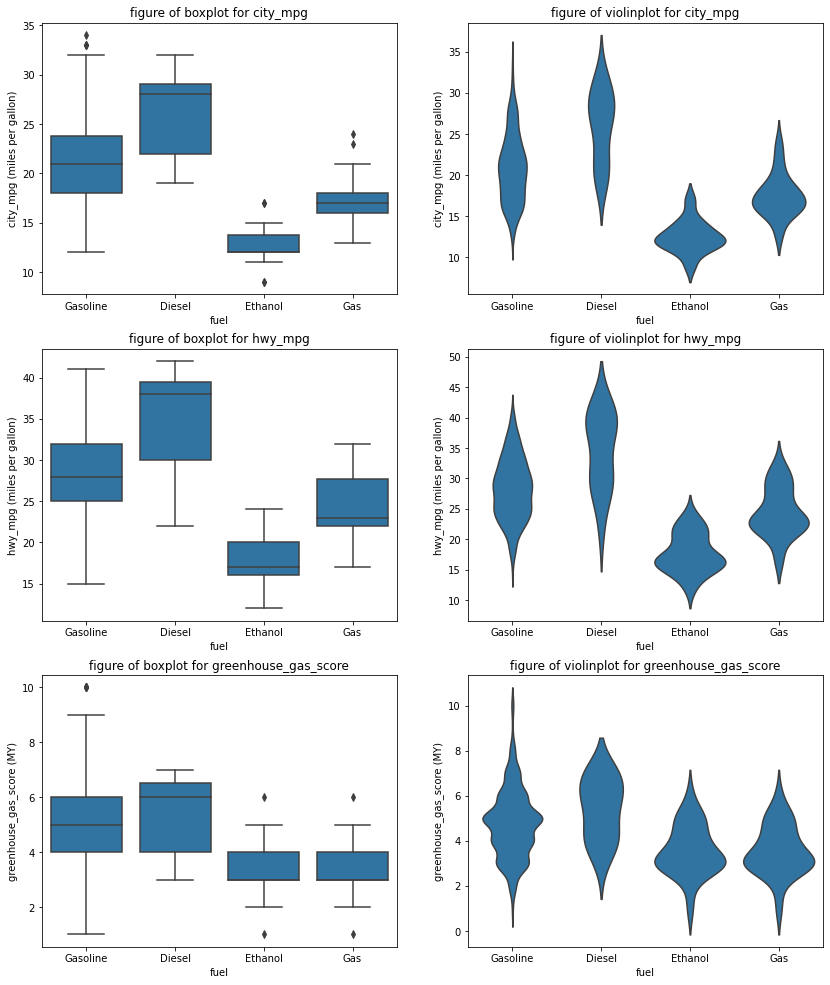

```python
fig,ax = plt.subplots(nrows=3, ncols=2 , figsize=[14,17])
for j in range(2):
    for i in range(2,5):
        if j==0:
            sb.boxplot(data=df2,x='fuel',y=var_numeric[i],color=color_base, ax=ax[i-2,j])
            ax[i-2,j].set_title('figure of boxplot for '+var_numeric[i])
        else:
            sb.violinplot(data=df2,x='fuel',y=var_numeric[i],color=color_base, inner=None, ax=ax[i-2,j])
            ax[i-2,j].set_title('figure of violinplot for '+var_numeric[i])
        ax[i-2,j].set_xlabel('fuel')
        ax[i-2,j].set_ylabel(var_numeric[i]+' '+unit_var[var_numeric[i]])
plt.show()
```

## comparing number of class of cars and all numeric variables

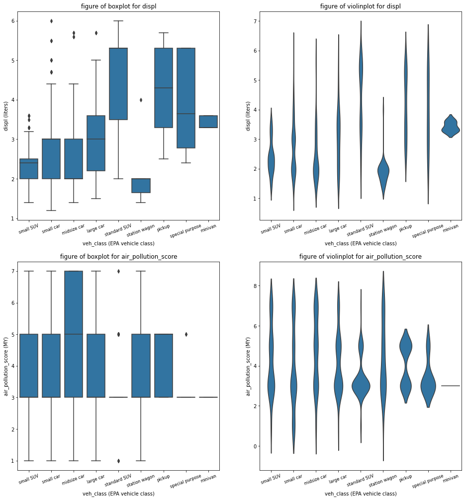

```python
fig,ax = plt.subplots(nrows=2, ncols=2 , figsize=[16,17])
for j in range(2):
    for i in range(2):
        if j==0:
            sb.boxplot(data=df2,x='veh_class',y=var_numeric[i],color=color_base, ax=ax[i,j])
            ax[i,j].set_title('figure of boxplot for '+var_numeric[i])
        else:
            sb.violinplot(data=df2,x='veh_class',y=var_numeric[i],color=color_base, inner=None, ax=ax[i,j])
            ax[i,j].set_title('figure of violinplot for '+var_numeric[i])
        ax[i,j].set_xlabel('veh_class (EPA vehicle class)')
        ax[i,j].set_ylabel(var_numeric[i]+' '+unit_var[var_numeric[i]])
        ax[i,j].set_xticklabels(df2['veh_class'].unique(),
                   rotation=20, fontsize='small')
plt.show()
```

## comparing number of class of cars and all numeric variables

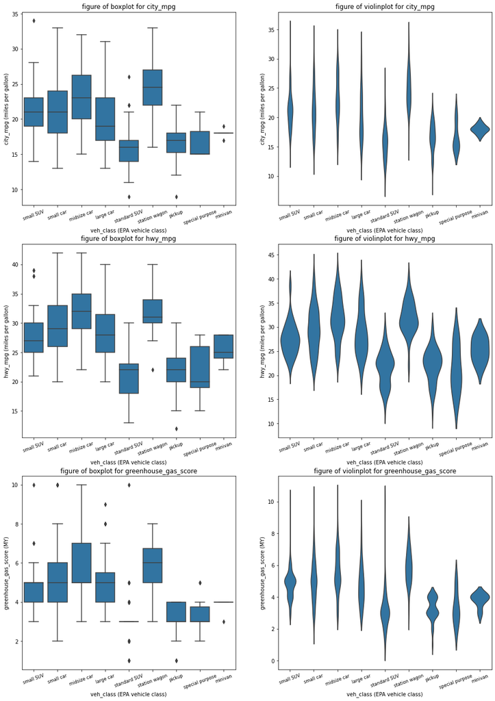

```python
fig,ax = plt.subplots(nrows=3, ncols=2 , figsize=[16,23])
for j in range(2):
    for i in range(2,5):
        if j==0:
            sb.boxplot(data=df2,x='veh_class',y=var_numeric[i],color=color_base, ax=ax[i-2,j])
            ax[i-2,j].set_title('figure of boxplot for '+var_numeric[i])
        else:
            sb.violinplot(data=df2,x='veh_class',y=var_numeric[i],color=color_base, inner=None, ax=ax[i-2,j])
            ax[i-2,j].set_title('figure of violinplot for '+var_numeric[i])
        ax[i-2,j].set_xlabel('veh_class (EPA vehicle class)')
        ax[i-2,j].set_ylabel(var_numeric[i]+' '+unit_var[var_numeric[i]])
        ax[i-2,j].set_xticklabels(df2['veh_class'].unique(),
                   rotation=20, fontsize='small')
plt.show()
```

### Discuss the distribution(s) of your variable(s) of interest. Were there any unusual points? Did you need to perform any transformations?

as we drawed of all distributions, 3 of them made histogram like normal. and others chart are readable and we got maximum and minimum point of them

### Of the features you investigated, were there any unusual distributions? Did you perform any operations on the data to tidy, adjust, or change the form of the data? If so, why did you do this?

as we considered relation between variables, we did not change form of data

## Multivariate Exploration

in this section, we want to consider relation between 3 variables. 2 numeric and one ordinal. as we got scatter chart in previous parts, we are willing to analysis relation 'veh_class' on numeric variables

## what is the relationship between two numeric variables in seperate parts of ordinal variabls?

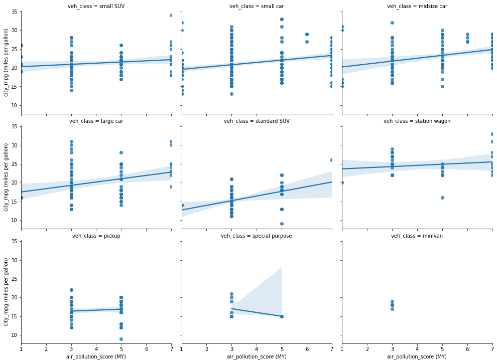

```python
g=sb.FacetGrid(data=df2,col='veh_class',size=4,col_wrap=3)
g.map(sb.regplot,'air_pollution_score','city_mpg')
g.set_xlabels('air_pollution_score '+unit_var['air_pollution_score'])
g.set_ylabels('city_mpg '+unit_var["city_mpg"])
g.fig.set_size_inches(14,10);
plt.show()
```

### we can see in these charts that we do not have strong relation between air pollution and city mpg. but for small car, midsize car, large car and standard SUV this relation is rarely positive

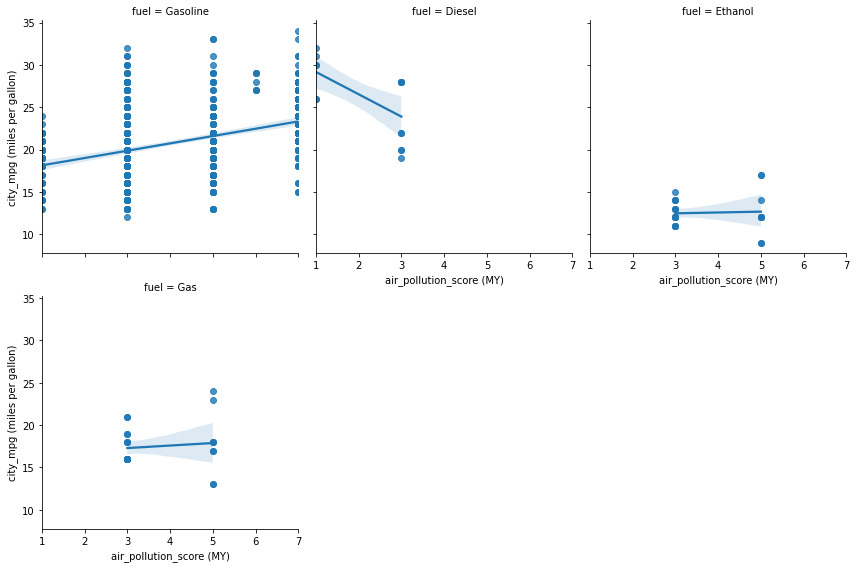

```python
g=sb.FacetGrid(data=df2,col='fuel',size=4,col_wrap=3)
g.map(sb.regplot,'air_pollution_score','city_mpg')
g.set_xlabels('air_pollution_score '+unit_var["air_pollution_score"])
g.set_ylabels('city_mpg '+unit_var["city_mpg"])
plt.show()
```

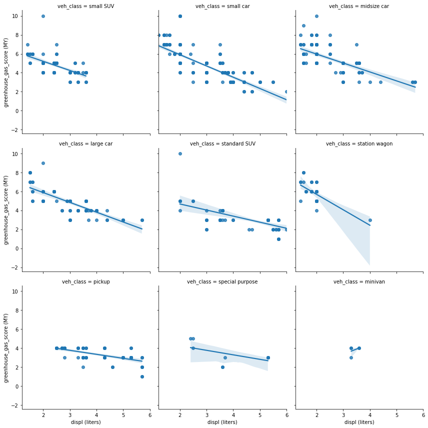

```python
g=sb.FacetGrid(data=df2,col='veh_class',size=4,col_wrap=3)
g.map(sb.regplot,'displ','greenhouse_gas_score')
g.set_xlabels('displ '+unit_var["displ"])
g.set_ylabels('greenhouse_gas_score '+unit_var["greenhouse_gas_score"])
plt.show()
```

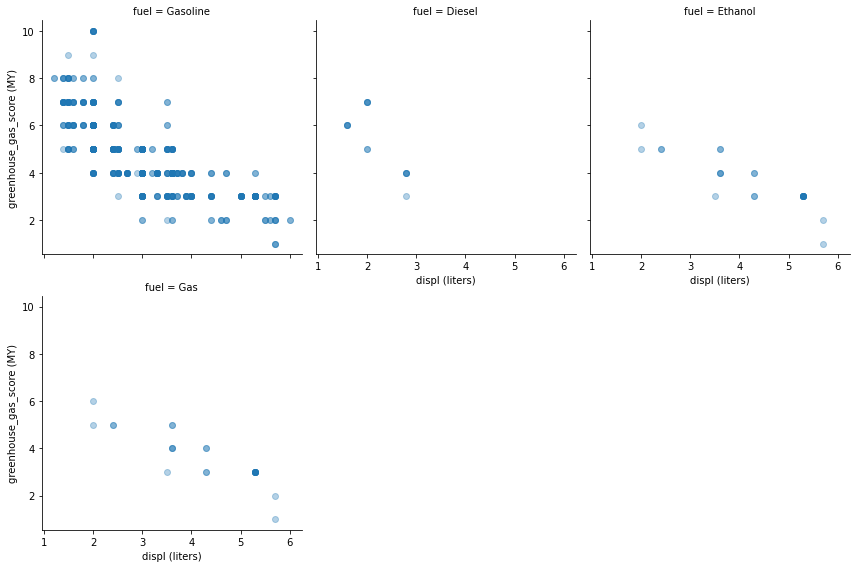

```python
g=sb.FacetGrid(data=df2,col='fuel',size=4,col_wrap=3)
g.map(plt.scatter,'displ','greenhouse_gas_score',alpha=1/3)
g.set_xlabels('displ '+unit_var["displ"])
g.set_ylabels('greenhouse_gas_score '+unit_var["greenhouse_gas_score"])
plt.show()
```

## what is the relationship between one numeric variable and one ordinal variable in seperate parts of other ordinal variable?

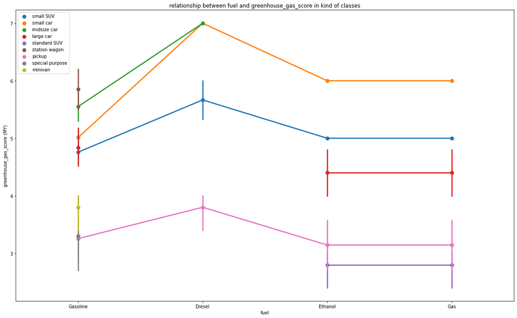

```python
plt.figure(figsize=[20,12])
sb.pointplot(data=df2,x='fuel',y='greenhouse_gas_score',hue='veh_class')
plt.legend(loc=2)
plt.xlabel("fuel")
plt.ylabel("greenhouse_gas_score "+unit_var["greenhouse_gas_score"])
plt.title("relationship between fuel and greenhouse_gas_score in kind of classes")
plt.show()
```

### Were there any interesting or surprising interactions between features?

one of the most interesting relation is between greenhouse_gas_score and displ in parts of class of car. by incrasing class of car we get negative relation between greenhouse_gas_score and displ. conversely we have positive relation between greenhouse_gas_score and city_mpg when size of cars increasing.

## Conclusions

```python
!jupyter nbconvert Part_II_slide_deck_template-checkpoint.ipynb --to slides --post serve --no-input --no-prompt
```

[output not shown]